# DETECTR 043 SpectraMax AMP and UMP Data - NANCY DREW

## AMP NEBuffer 4 + 2.1 Thawed Standard Curves for concentrations from 0.01uM to 10uM, including 0uM

- 0hr and 1hr single time points are first two plots
- Summation of all data points below 1hr, 3hr, 6hr and 12hr are next four plots
- Used standard curve from DETECTR 042 (with ATP)

### Conclusion

Same as before - 1hr looks better than 0hr and summing helps slightly reduce noise.

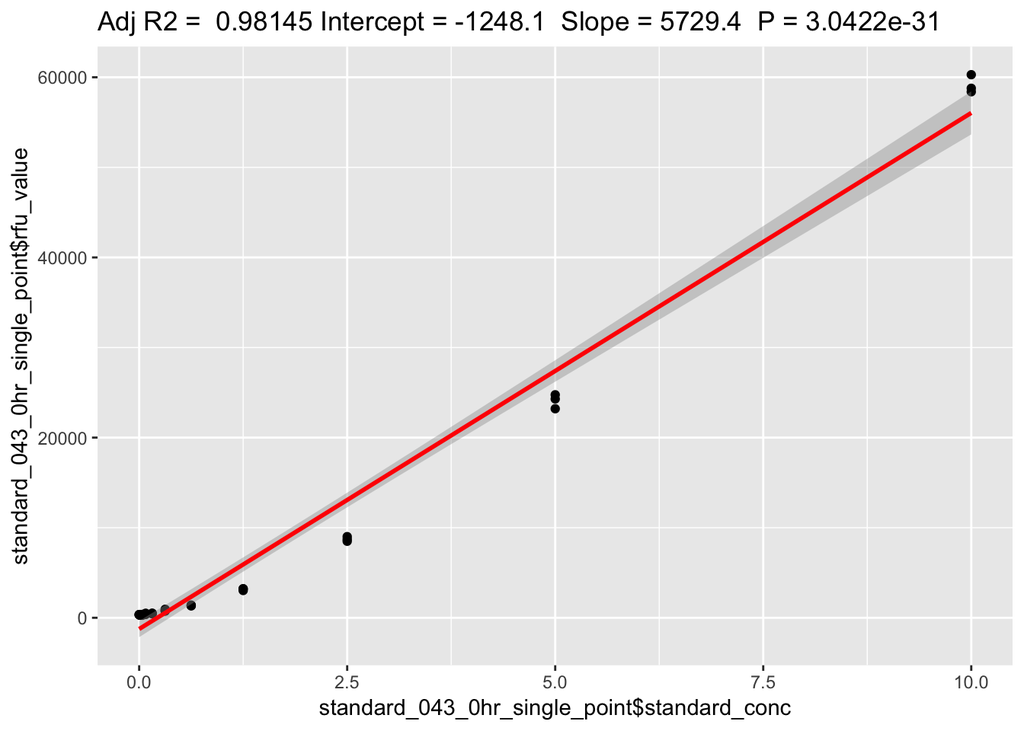

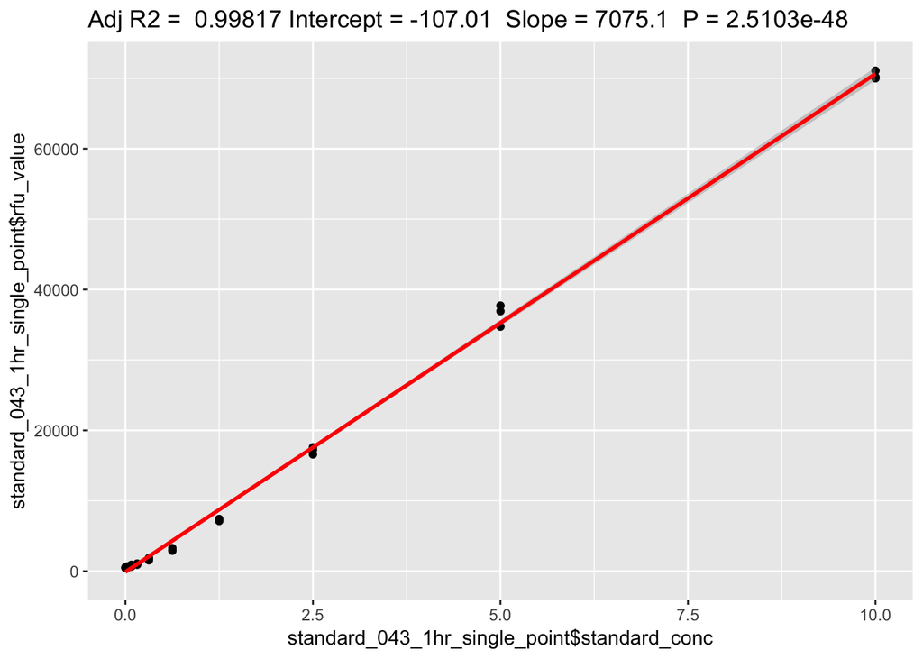

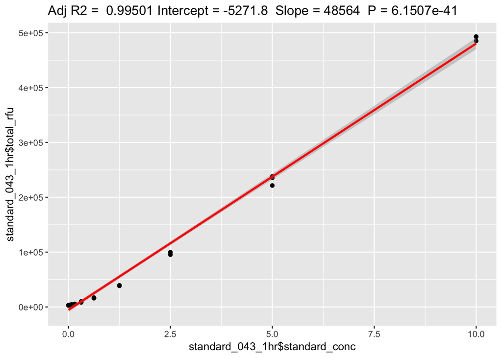

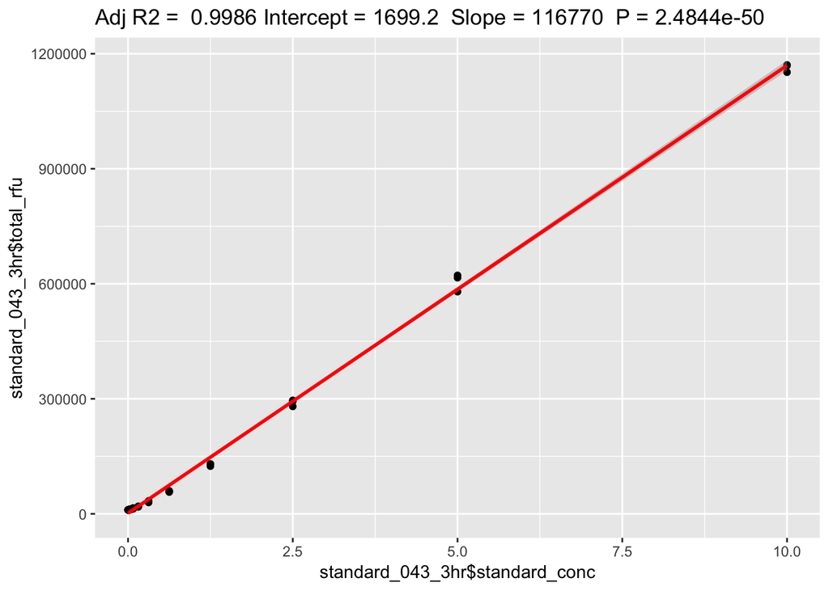

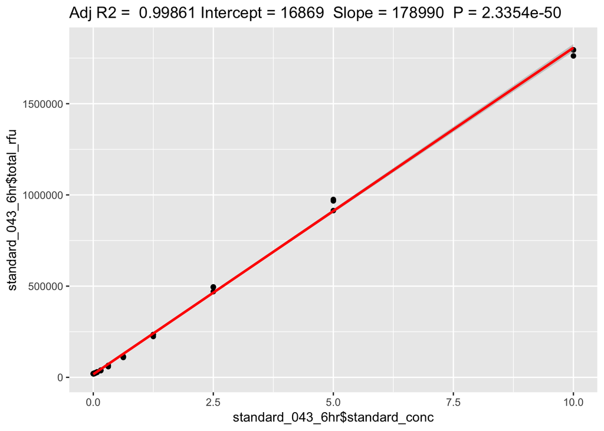

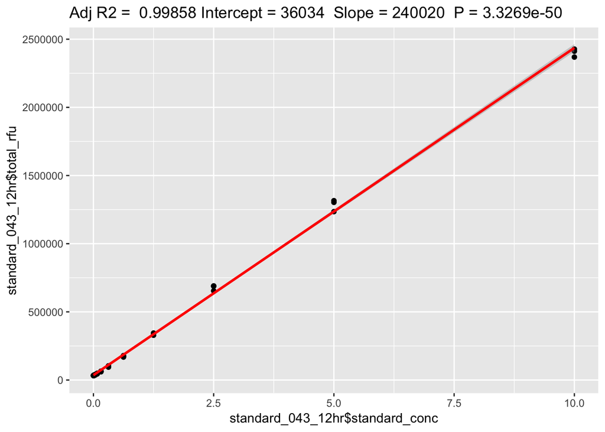

## AMP NEBuffer 4+ 2.1 Thawed Standard Curves for concentrations from 0.01uM to 0.625uM, including 0uM

- 0hr and 1hr single time points are first two plots
- Summation of all data points below 1hr, 3hr, 6hr and 12hr are next four plots
- Used standard curve from DETECTR 042 (with ATP)

### Conclusion

Same as before - summing reduces noise quite a bit. Can detect down to 0.08 uM.

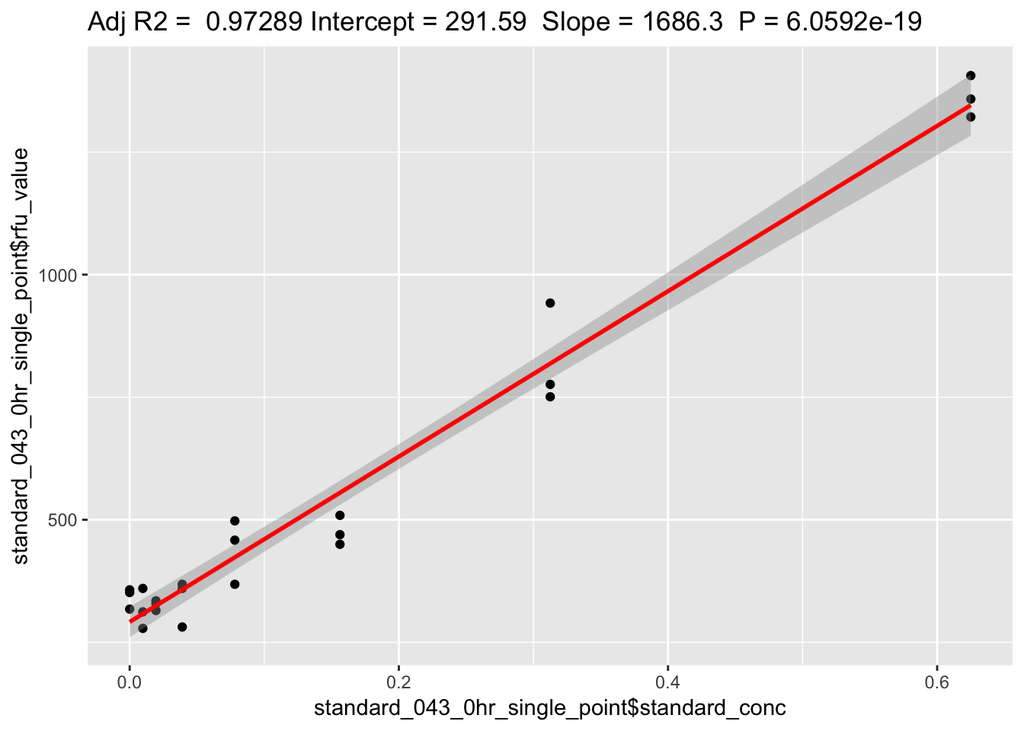

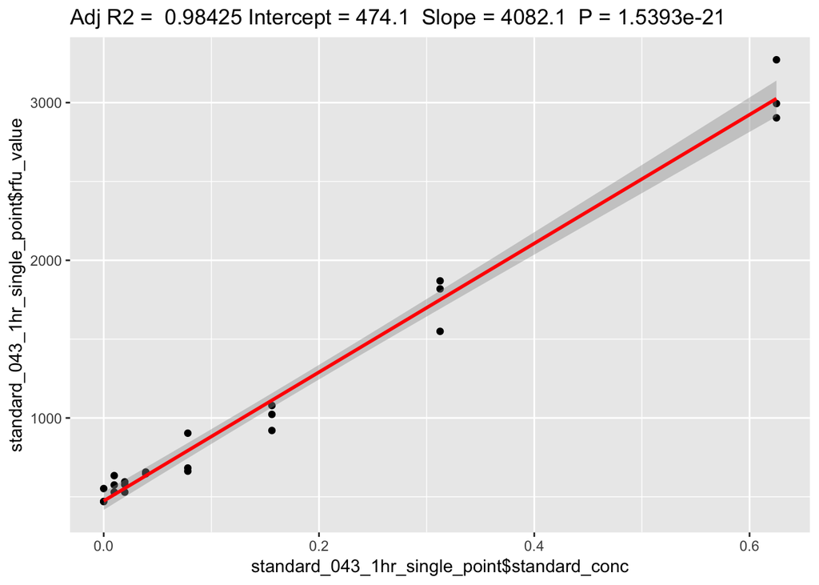

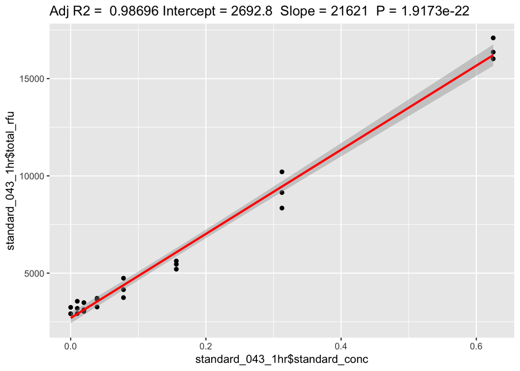

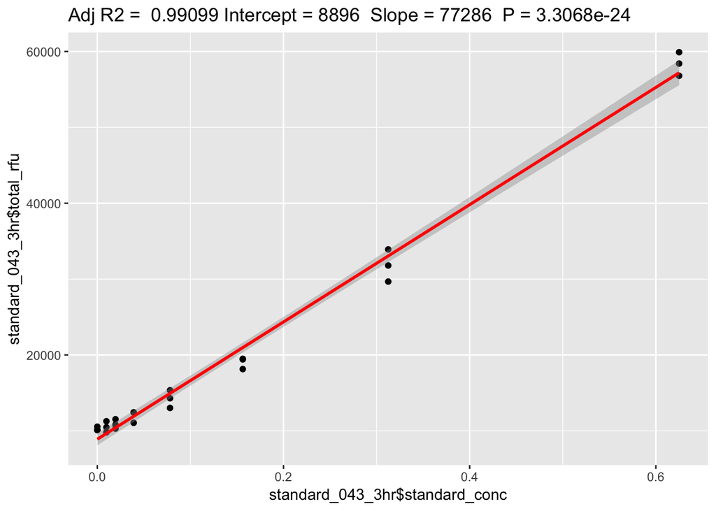

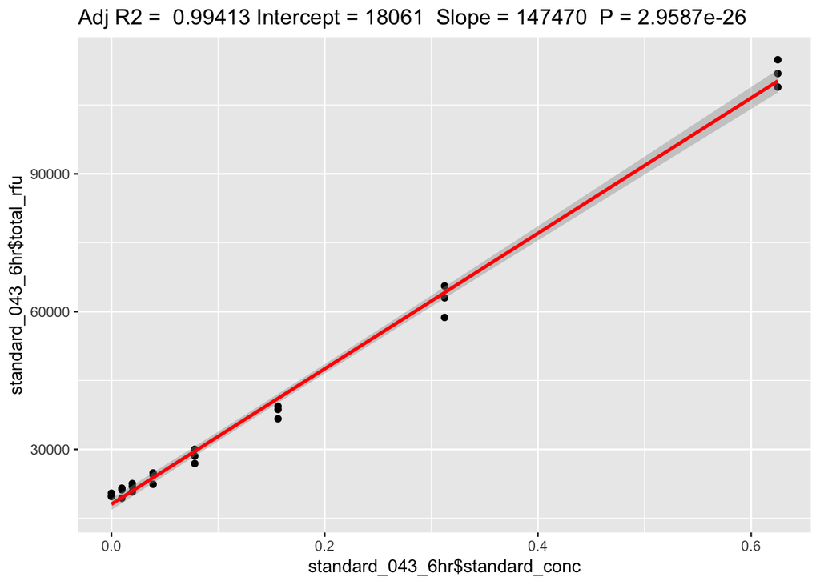

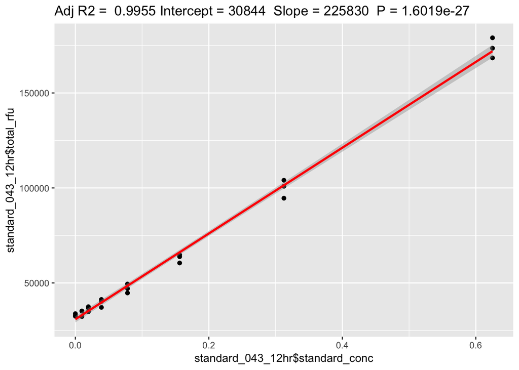

## UMP NEBuffer 4 + 2.1 Fresh Standard Curves for concentrations from 0.01uM to 10uM, including 0uM

- 0hr and 1hr single time points are first two plots
- Summation of all data points below 1hr is next plot
- Did not read overnight, only read AMP GLO overnight

### Conclusion

1 hr is better than 0 hr. Summing reduces noise quite a bit.

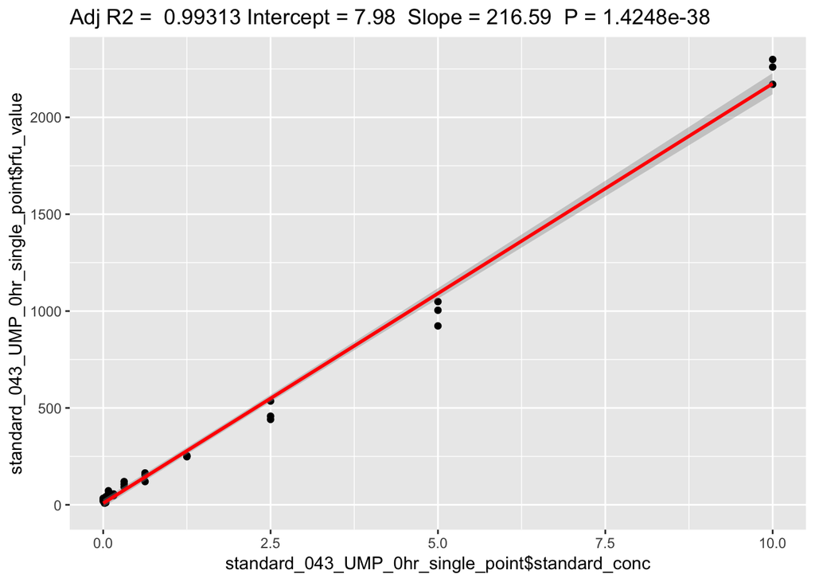

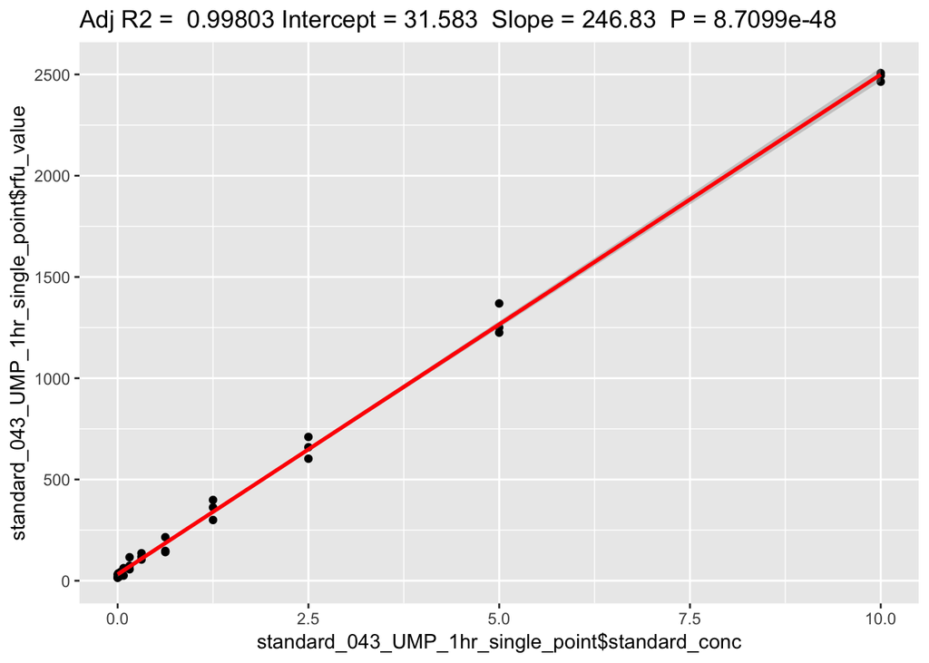

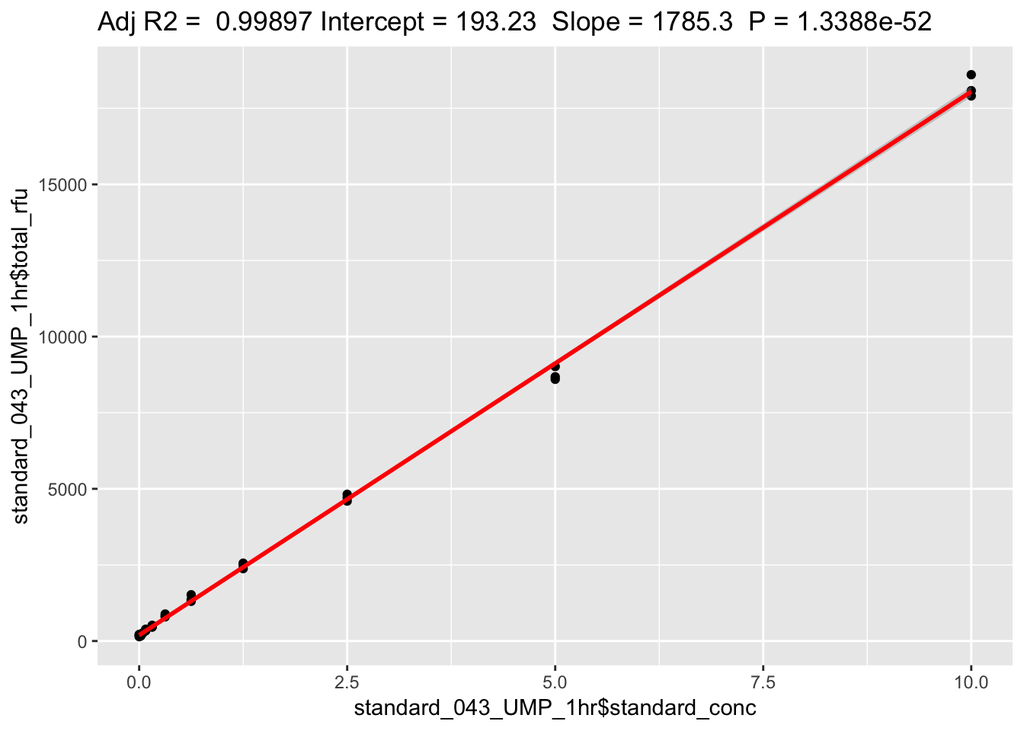

## UMP NEBuffer 4 + 2.1 Fresh Standard Curves for concentrations from 0.01uM to 0.625uM, including 0uM

- 0hr and 1hr single time points are first two plots
- Summation of all data points below 1hr is next plot
- Did not read overnight, only read AMP GLO overnight

### Conclusion

Summing significantly helps with lower concentrations. Can MAYBE detect down to 0.04uM.

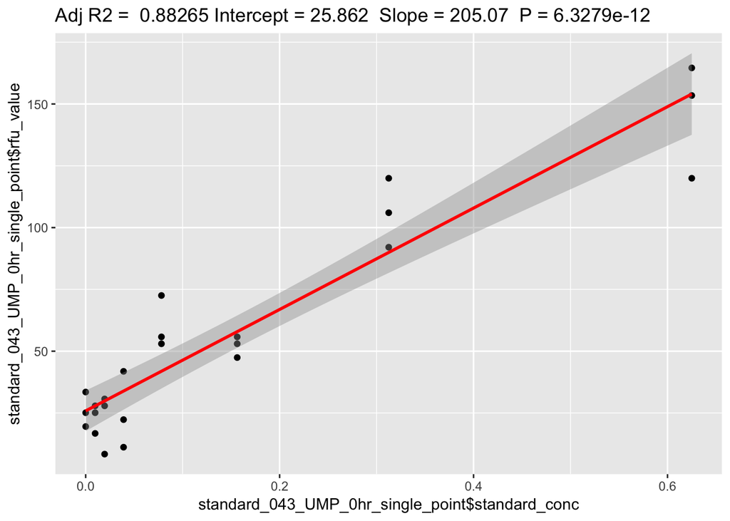

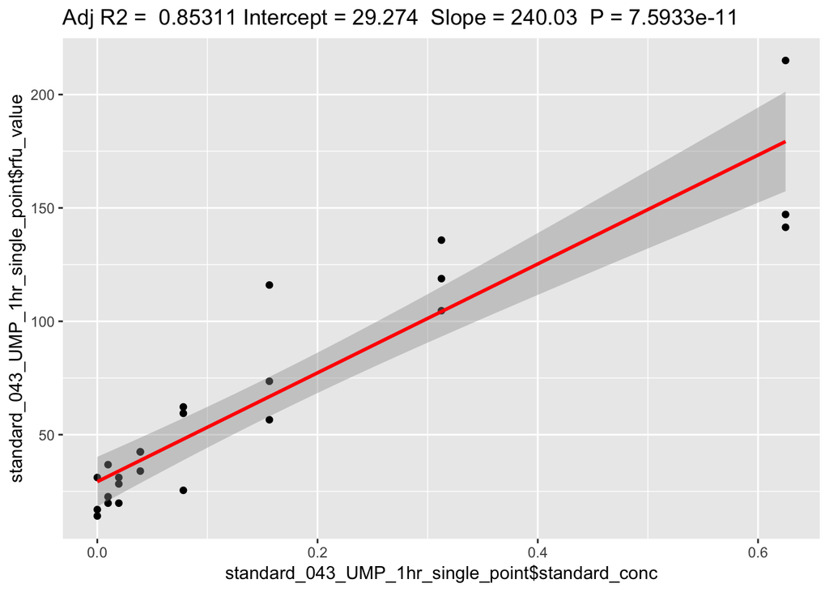

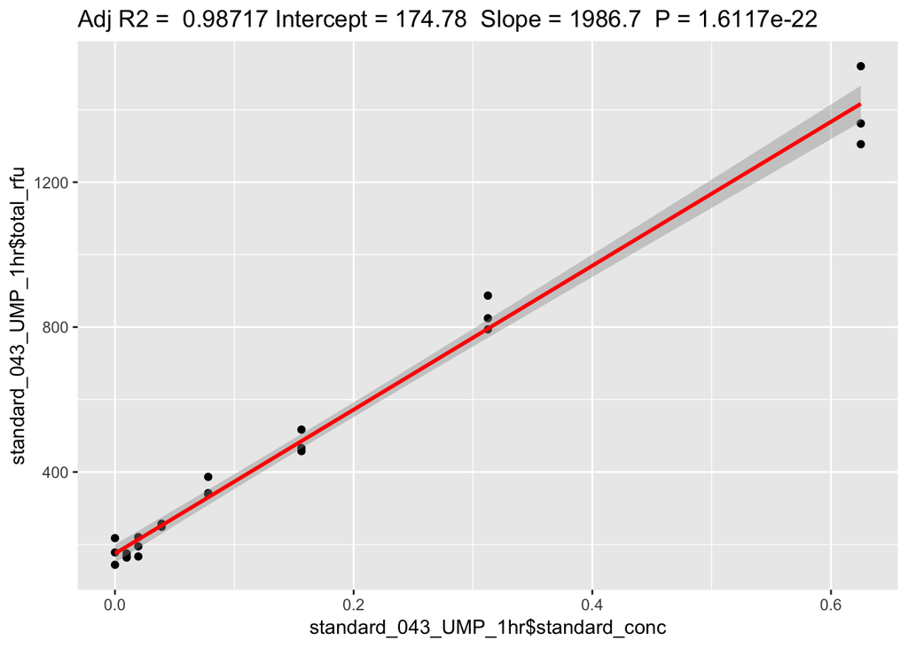

## Testing UMP GLO NANCY DREW

- Used IDT cas12a and synthetic 11C gRNA with synthetic 11C target for all
- All UMP samples had the r17U-TTATT-phos reporter
- RFU values were converted to UMP uM concentrations using the 1hr summation regression

### Conclusions

UMP GLO NANCY DREW works! It has a little bit of background (0.37uM), but a really strong signal (18.2uM).

| gRNA | reporter | target | RNAseT | kit | mean_rfu_value | sd_rfu_value | mean_amp | sd_amp | sample_name |
| --- | --- | --- | --- | --- | --- | --- | --- | --- | --- |
| no_gRNA | r17U-TTATT-phos | target_added | RNAseT | UMP | 458.7973 | 35.24597 | 0.14875222 | 0.01974232 | no_gRNA |
| syn_11C | no_reporter | target_added | RNAseT | UMP | 1363.0430 | 254.65773 | 0.65524730 | 0.14264142 | no_reporter |
| syn_11C | r17U-TTATT-phos | no_target | RNAseT | UMP | 859.0260 | 30.39445 | 0.37293228 | 0.01702484 | no_target |
| syn_11C | r17U-TTATT-phos | target_added | no_RNAseT | UMP | 251.4630 | 15.15150 | 0.03261805 | 0.00848681 | no_RNAseT |
| syn_11C | r17U-TTATT-phos | target_added | RNAseT | UMP | 32765.4117 | 996.43655 | 18.24465449 | 0.55813395 | target_added |

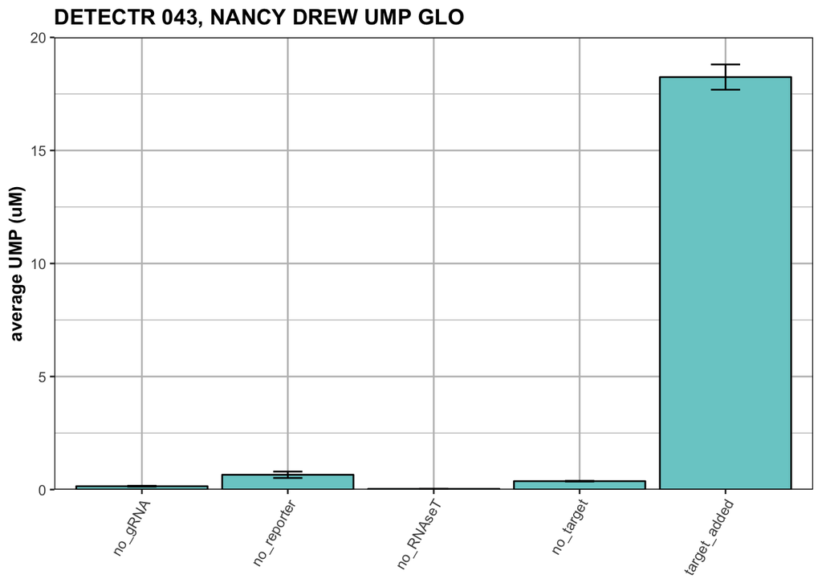

## AMP GLO NANCY DREW Controls

- Used IDT cas12a and synthetic 11C gRNA with synthetic 11C target for all
- r17A-AAAAA-phos reporter had no gRNA, no RNAseT, and no target controls
- r17Ar3C and r17A-TTATT-r3C had no target control
- No reporter control serves as negative control for all reporter
- RFU values were converted to AMP uM concentrations using the 1hr summation regression

### Conclusions

Confusingly, all the signals are lower this time than last time, despite the standard curve looking roughly the same. The r17A-AAAAA-phos signal is 10uM instead of 15uM, but most shocking is that the r17Ar3C signal went from 30uM to 5uM. The 5uM signal for r17Ar3C is more in line with what I would expect to see based on previous experiments (see DETECTR 029, 034, 035). The r17A-TTATT-r3C reporter works, contrary to the last experiment we did in 2XBB when it didn’t work. However, it has a really large background.

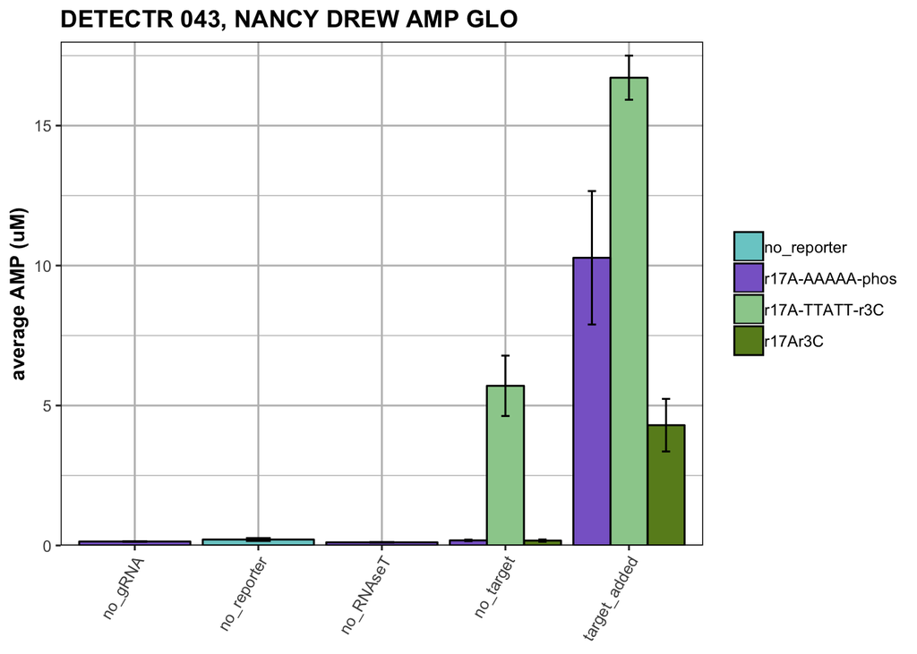

## UMP and AMP compared

### Conclusions

UMP reporter is looking good, though it has twice the background of the AMP reporters.

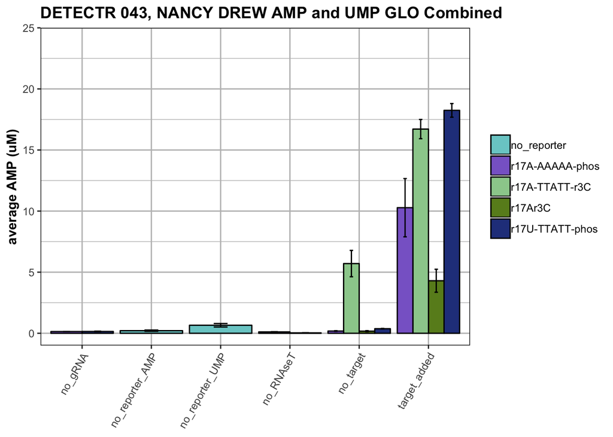

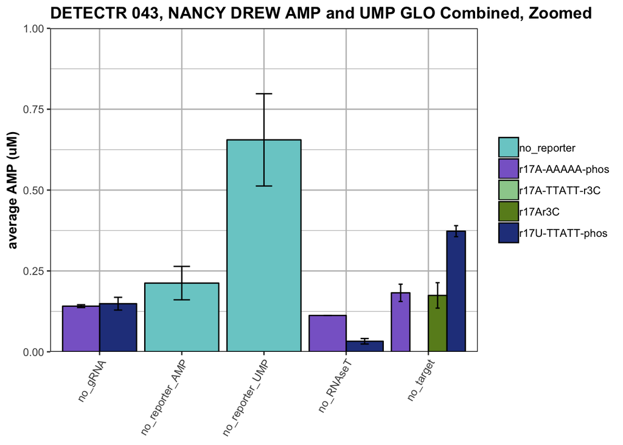

## Kinetics over time, UMP and AMP

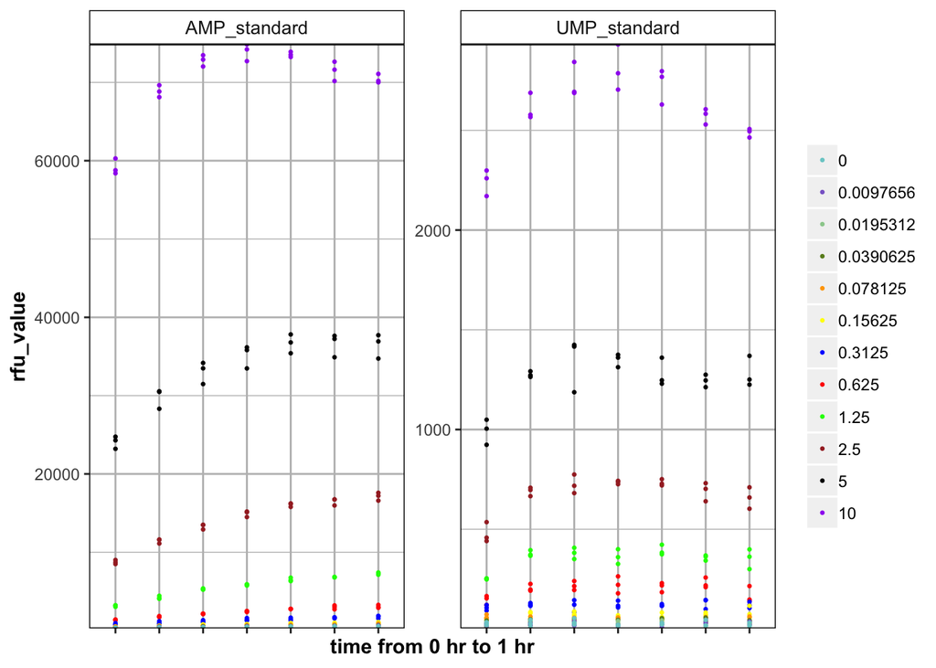